# The Air Quality Dataset

Johnson W. Ahiadorme

6/12/2019

## Summary of Air Quality Dataset

- **Ozone**: Mean ozone in parts per billion *(ppb)* from 1300 to 1500 hours at Roosevelt Island;
- **Solar.R**: Solar radiation in Langleys *(lang)* in the frequency band 4000–7700 Angstroms from 0800 to 1200 hours at Central Park;
- **Wind**: Average wind speed in miles per hour *(mph)* at 0700 and 1000 hours at LaGuardia Airport;
- **Temp**: Maximum daily temperature in degrees Fahrenheit *(oF)* at LaGuardia Airport;
- **Month**: numeric month *(1-12)* **Day**: numeric Day of the month *(1-31)*

Here is a summary of the data

```
##      Ozone           Solar.R           Wind             Temp
##  Min.   :  1.00   Min.   :  7.0   Min.   : 1.700   Min.   :56.00
##  1st Qu.: 18.00   1st Qu.:115.8   1st Qu.: 7.400   1st Qu.:72.00
##  Median : 31.50   Median :205.0   Median : 9.700   Median :79.00
##  Mean   : 42.13   Mean   :185.9   Mean   : 9.958   Mean   :77.88
##  3rd Qu.: 63.25   3rd Qu.:258.8   3rd Qu.:11.500   3rd Qu.:85.00
##  Max.   :168.00   Max.   :334.0   Max.   :20.700   Max.   :97.00
##  NA's   :37       NA's   :7
##      Month            Day
##  Min.   :5.000   Min.   : 1.0
##  1st Qu.:6.000   1st Qu.: 8.0
##  Median :7.000   Median :16.0
##  Mean   :6.993   Mean   :15.8
##  3rd Qu.:8.000   3rd Qu.:23.0
##  Max.   :9.000   Max.   :31.0
##
```

### Table of Top of the Air Quality Dataset

A table of the head of the air quality dataset

Top of the Air Quality Dataset

| Ozone | Solar.R | Wind | Temp | Month | Day |
| --- | --- | --- | --- | --- | --- |
| 41 | 190 | 7.4 | 67 | 5 | 1 |
| 36 | 118 | 8.0 | 72 | 5 | 2 |
| 12 | 149 | 12.6 | 74 | 5 | 3 |
| 18 | 313 | 11.5 | 62 | 5 | 4 |
| NA | NA | 14.3 | 56 | 5 | 5 |
| 28 | NA | 14.9 | 66 | 5 | 6 |

### Plot of Ozone by Temperature –Air Quality Dataset

A plot of the temperature and ozone from the built-in air quality dataset

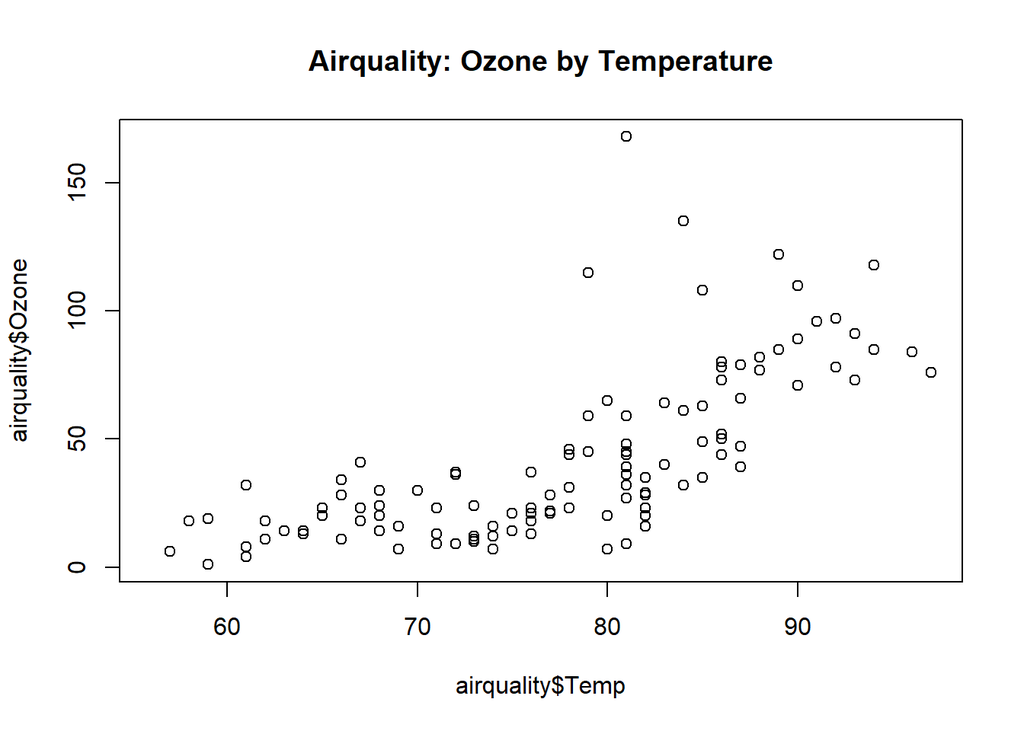

[^1]: Chambers, J. M., Cleveland, W. S., Kleiner, B. and Tukey, P. A. (1983) Graphical Methods for Data Analysis. Belmont, CA: Wadsworth.